# R Notebook

### Assigment 1

Prepare the given data!

```r
s = 14
f = 6
a0 = 2
b0 = 2
```

#### 1a

We use the rbeta function to draw from the posterior distribution. The calucations for true mean and deviations are taken from https://en.wikipedia.org/wiki/Beta_distribution.

```r
nr_of_draws = 1000

post_means = c()
post_devs = c()

for (i in 1:nr_of_draws) {
  post_means = c(post_means,mean(rbeta(i,a0+s,b0+f)))
  post_devs = c(post_devs,sd(rbeta(i,a0+s,b0+f)))
}
```

Plot the mean as the number of draws increases. The red line shows the true mean

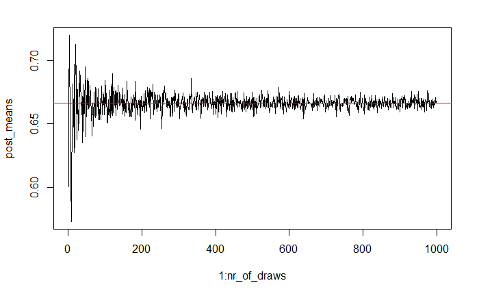

```r
true_mean = (a0+s)/(a0+s+b0+f)
plot(1:nr_of_draws,post_means,type="l")
abline(h=true_mean,col="red")
```

Plot the deviation also as the number of draws increases. Red line represents the true deviation.

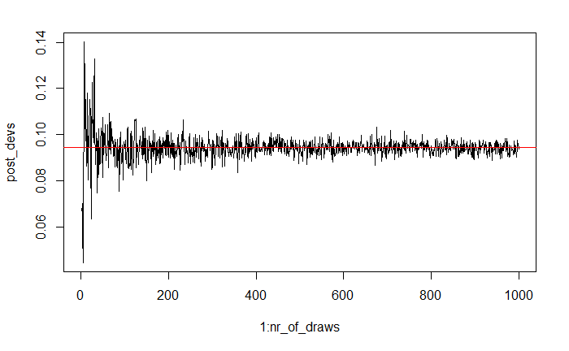

```r
true_var = (a0+s)*(b0+f)/((a0+s+b0+f)^2*(a0+s+b0+f+1))
plot(1:nr_of_draws,post_devs,type="l")
abline(h=sqrt(true_var),col="red")
```

#### 1b

Draw from the posterior using rbeta and just count the values that are less then the given threshold.

```r
draws = rbeta(10000,a0+s,b0+f)
dprob = NROW(draws[draws < 0.4])/NROW(draws)
bprob = pbeta(0.4,a0+s,b0+f)
print(sprintf("Draw-prob = %f and Beta-prob = %f",dprob,bprob))
```

```
[1] "Draw-prob = 0.003700 and Beta-prob = 0.003973"
```

#### 1c

Use the draw results from 1b and transform them into log-odds.

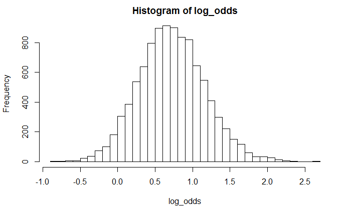

```r
log_odds = log(draws/(1-draws))
hist(log_odds,breaks=50)
```

### Assigment 2

Preparations!

```r
u = 3.5
income = c(14,25,45,25,30,33,19,50,34,67)
tau2 = sum(log(income)-u)^2/length(income)
```

#### 2a

The geoR::rinvchisq function simulates draws from scaled inverse chi-square distribution. From the assigment, we have two parameters n and $\tau^2$ represented as scale and df (degree of freedom) paramaters to the geoR::rinvchisq function. Generate draws and plot it with the density function (geoR::dinvchisq). The blue line represent the true distribution.

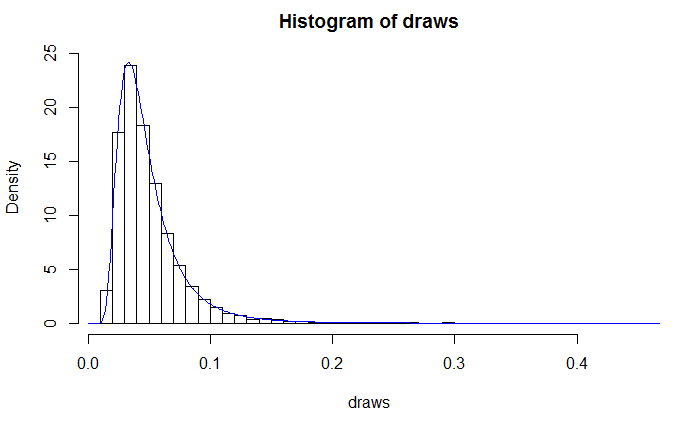

```r
draws = geoR::rinvchisq(10000,df=length(income),scale=tau2);
# Offset not defined for 0
x = 0:1000/1000+1/100000;
h = hist(draws,breaks=50,plot=FALSE)
d = geoR::dinvchisq(x,df=length(income),scale=tau2)
ymax = max(h$density,d)+1;
plot(h,ylim=c(0,ymax),freq=FALSE)
lines(x,d,col="blue")
```

#### 2b

The built in pnorm function gives us the CDF that is normally distributed. Using the results from 2a, we can plot the values from the Gini coefficient.

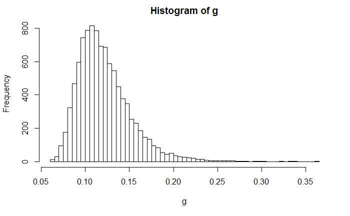

```r
g = 2*pnorm(sqrt(draws)/sqrt(2))-1
hist(g,breaks = 50)
```

#### 2c

Take out 2.5% from each tail in the distribution and density function, plot them to see visually the difference.

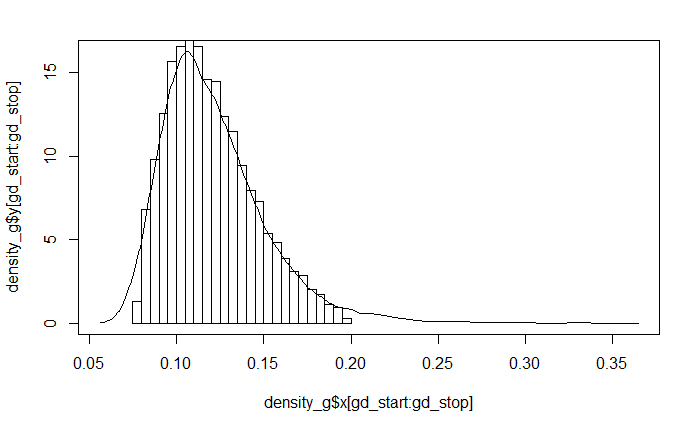

```r
g = g[order(g)];
g_start = floor(length(g)*0.025)
g_stop = floor(length(g)*0.975)
density_g = density(g)
gd_start = floor(length(density_g$x)*0.025)
gd_stop = floor(length(density_g$x)*0.975)
plot(density_g$x[gd_start:gd_stop],density_g$y[gd_start:gd_stop],type="l")
hist(g[g_start:g_stop],add=TRUE,freq=FALSE,breaks =30)
```

### Assigment 3

The data points is following a von Mises distribution, the likelihood function is given by:
$$p(y \mid \kappa, \mu) = \frac{exp[\kappa*cos(y-\mu])}{2\pi I_0(\kappa)}$$
Where $I_0$ is the Bessel function. The prior is following an exponential distribution given by $f(\kappa;\lambda) = \lambda e^{-\lambda \kappa}$ when $x \geq 0$. Given that the data points are i.i.d, the following posterior can be derived for n osbervations and $x \geq 0$, excluding the scaling parameter.

$$p(k \mid y, \mu) \propto (\prod_{i=1}^{n}{p(y_n \mid \kappa, \mu))*f(\kappa;\lambda)
}$$

```r
obs = c(-2.44,2.14,2.54,1.83,2.02,2.33,-2.79,2.23,2.07,2.02)
lambda = 1
mu = 2.39
von_mises_prob = function(kappa,y,mu) {return(exp(kappa*cos(y-mu))/(2*pi*besselI(kappa,0)))};
```

#### 3a

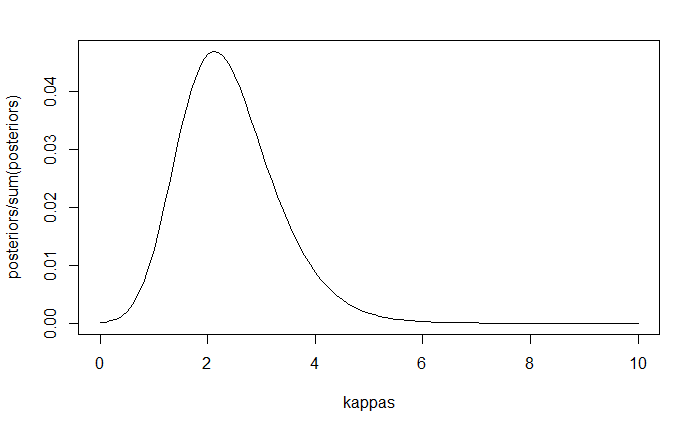

```r
grid_spacing = 0.1;
grid_max = 10;
kappas = seq(0,grid_max,by=grid_spacing)
posteriors = c()
for (i in 1:length(kappas)) {
    posteriors = c(posteriors,prod(exp(kappas[i]*cos(y-mu))/(2*pi*besselI(kappas[i],0)))*dexp(kappas[i],rate=lambda))
}
plot(kappas,posteriors/sum(posteriors),type="l")
```

#### 3b

```r
kp_max = kappas[which.max(posteriors)]
print(sprintf("kappa = %f",kp_max))
```

```
[1] "kappa = 2.100000"
```